# Modeling the Expert: Intro. Logistic Regression

2022-05-09

```r
library(caTools)
library(ROCR)
```

## Quick Question

Which of the following dependent variables (因變量) are categorical (分類)? (Select all that apply.)

```r
# Deciding whether to buy, sell, or hold a stock   # T
# The weekly revenue of a company                  #
# The winner of an election with two candidates    # T
# The day of the week with the highest revenue     # T
# The number of daily car thefts in New York City  #
# Whether or not revenue will exceed $50,000       # T
```

Which of the following dependent variables are binary (二元) ? (Select all that apply.)

```r
# Deciding whether to buy, sell, or hold a stock   #
# The weekly revenue of a company                  #
# The winner of an election with two candidates    # T
# The day of the week with the highest revenue     #
# The number of daily car thefts in New York City  #
# Whether or not revenue will exceed $50,000       # T
```

## Quick Question

Suppose the coefficients of a logistic regression model with two independent variables are as follows:

$\beta_0 = -1.5,\beta_1 = 3,\beta_2 = -0.5$

And we have an observation with the following values for the independent variables:

$x_1 = 1,x_2 = 5$

What is the value of the Logit for this observation? Recall that the Logit is log(Odds).

$odd = Exp(logit) = \frac{p}{1-p}$

$logit = f(x) = b_0 + b_1 x_1 + b_2 x_2 = log(odd) = log(\frac{p}{1-p})$

```r
b = c(-1.5, 3, -0.5)
logit = sum(b * c(1, 1, 5))
logit
```

```
## [1] -1
```

What is the value of the Odds for this observation? Note that you can compute e^x, for some number x, in your R console by typing exp(x). The function exp() computes the exponential of its argument.

```r
odd = exp(logit)
odd
```

```
## [1] 0.3678794
```

What is the value of P(y = 1) for this observation?

```r
prob = odd/(1+odd)
prob
```

```
## [1] 0.2689414
```

```r
quality = read.csv('C:/cm502/Unit3/quality.csv')
str(quality)
```

```
## 'data.frame':    131 obs. of  14 variables:
##  $ MemberID            : int  1 2 3 4 5 6 7 8 9 10 ...
##  $ InpatientDays       : int  0 1 0 0 8 2 16 2 2 4 ...
##  $ ERVisits            : int  0 1 0 1 2 0 1 0 1 2 ...
##  $ OfficeVisits        : int  18 6 5 19 19 9 8 8 4 0 ...
##  $ Narcotics           : int  1 1 3 0 3 2 1 0 3 2 ...
##  $ DaysSinceLastERVisit: num  731 411 731 158 449 ...
##  $ Pain                : int  10 0 10 34 10 6 4 5 5 2 ...
##  $ TotalVisits         : int  18 8 5 20 29 11 25 10 7 6 ...
##  $ ProviderCount       : int  21 27 16 14 24 40 19 11 28 21 ...
##  $ MedicalClaims       : int  93 19 27 59 51 53 40 28 20 17 ...
##  $ ClaimLines          : int  222 115 148 242 204 156 261 87 98 66 ...
##  $ StartedOnCombination: logi  FALSE FALSE FALSE FALSE FALSE FALSE ...
##  $ AcuteDrugGapSmall   : int  0 1 5 0 0 4 0 0 0 0 ...
##  $ PoorCare            : int  0 0 0 0 0 1 0 0 1 0 ...
```

```r
table(quality$PoorCare)
```

```
##
##  0  1
## 98 33
```

## sample.split ：將數據拆分為測試集和訓練集

將向量Y中的數據以預定義的比例拆分為兩組，同時保留Y中不同標籤的相對比例 用於將分類期間使用的數據拆分為訓練和測試子集

```r
set.seed(88)

split = sample.split(quality$PoorCare, SplitRatio = 0.75) # 75% - 25%
split # 用T & F分出訓練 & 測試集
```

```
##   [1]  TRUE  TRUE  TRUE  TRUE FALSE  TRUE FALSE  TRUE FALSE FALSE  TRUE FALSE
##  [13]  TRUE  TRUE  TRUE  TRUE  TRUE  TRUE  TRUE  TRUE  TRUE  TRUE  TRUE  TRUE
##  [25] FALSE  TRUE  TRUE  TRUE  TRUE FALSE FALSE FALSE FALSE  TRUE  TRUE  TRUE
##  [37] FALSE  TRUE  TRUE  TRUE FALSE FALSE  TRUE  TRUE FALSE  TRUE FALSE  TRUE
##  [49] FALSE  TRUE  TRUE FALSE FALSE  TRUE  TRUE  TRUE  TRUE  TRUE  TRUE  TRUE
##  [61]  TRUE  TRUE  TRUE  TRUE  TRUE FALSE  TRUE  TRUE  TRUE  TRUE FALSE  TRUE
##  [73]  TRUE  TRUE  TRUE  TRUE  TRUE  TRUE  TRUE  TRUE  TRUE  TRUE  TRUE FALSE
##  [85]  TRUE  TRUE  TRUE  TRUE  TRUE  TRUE  TRUE  TRUE  TRUE FALSE  TRUE  TRUE
##  [97]  TRUE  TRUE  TRUE  TRUE  TRUE  TRUE  TRUE FALSE  TRUE  TRUE  TRUE FALSE
## [109]  TRUE FALSE FALSE  TRUE  TRUE FALSE  TRUE  TRUE  TRUE FALSE  TRUE  TRUE
## [121] FALSE  TRUE  TRUE FALSE  TRUE  TRUE FALSE  TRUE  TRUE  TRUE FALSE
```

```r
qualityTrain = subset(quality, split == TRUE)
qualityTest = subset(quality, split == FALSE)
nrow(qualityTrain)
```

```
## [1] 99
```

```r
nrow(qualityTest)
```

```
## [1] 32
```

```r
QualityLog = glm(PoorCare ~ OfficeVisits + Narcotics,
                 data = qualityTrain, family = binomial)
summary(QualityLog)
```

```
##
## Call:
## glm(formula = PoorCare ~ OfficeVisits + Narcotics, family = binomial,
##     data = qualityTrain)
##
## Deviance Residuals:
##      Min        1Q    Median        3Q       Max
## -2.06303  -0.63155  -0.50503  -0.09689   2.16686
##
## Coefficients:
##              Estimate Std. Error z value Pr(>|z|)
## (Intercept)  -2.64613    0.52357  -5.054 4.33e-07 ***
## OfficeVisits  0.08212    0.03055   2.688  0.00718 **
## Narcotics     0.07630    0.03205   2.381  0.01728 *
## ---
## Signif. codes:  0 '***' 0.001 '**' 0.01 '*' 0.05 '.' 0.1 ' ' 1
##
## (Dispersion parameter for binomial family taken to be 1)
##
##     Null deviance: 111.888  on 98  degrees of freedom
## Residual deviance:  89.127  on 96  degrees of freedom
## AIC: 95.127
##
## Number of Fisher Scoring iterations: 4
```

```r
predictTrain = predict(QualityLog, type = 'response')
summary(predictTrain)
```

```
##    Min. 1st Qu.  Median    Mean 3rd Qu.    Max.
## 0.06623 0.11912 0.15967 0.25253 0.26765 0.98456
```

```r
tapply(predictTrain, qualityTrain$PoorCare, mean)
```

```
##         0         1
## 0.1894512 0.4392246
```

## Quick Question

In R, create a logistic regression model to predict “PoorCare” using the independent variables “StartedOnCombination” and “ProviderCount”.  
Use the training set we created in the previous video to build the model.

quality = read.csv(“quality.csv”)

install.packages(“caTools”)

library(caTools)

set.seed(88)

split = sample.split(quality$PoorCare, SplitRatio = 0.75)

qualityTrain = subset(quality, split == TRUE)

qualityTest = subset(quality, split == FALSE)

Then recall that we built a logistic regression model to predict PoorCare using the R command:

QualityLog = glm(PoorCare ~ OfficeVisits + Narcotics, data=qualityTrain, family=binomial)

You will need to adjust this command to answer this question, and then look at the summary(QualityLog) output.

What is the coefficient for “StartedOnCombination”?

```r
set.seed(88)

split_1 = sample.split(quality$PoorCare, SplitRatio = 0.75)

qualityTrain_1 = subset(quality, split == TRUE)

qualityTest_1 = subset(quality, split == FALSE)

QualityLog_1 = glm(PoorCare ~ StartedOnCombination + ProviderCount,
                 data=qualityTrain_1, family=binomial)
summary(QualityLog_1)
```

```
##
## Call:
## glm(formula = PoorCare ~ StartedOnCombination + ProviderCount,
##     family = binomial, data = qualityTrain_1)
##
## Deviance Residuals:
##      Min        1Q    Median        3Q       Max
## -1.61826  -0.72782  -0.64555  -0.08407   1.94662
##
## Coefficients:
##                          Estimate Std. Error z value Pr(>|z|)
## (Intercept)              -2.00097    0.55097  -3.632 0.000282 ***
## StartedOnCombinationTRUE  1.95230    1.22342   1.596 0.110541
## ProviderCount             0.03366    0.01983   1.697 0.089706 .
## ---
## Signif. codes:  0 '***' 0.001 '**' 0.01 '*' 0.05 '.' 0.1 ' ' 1
##
## (Dispersion parameter for binomial family taken to be 1)
##
##     Null deviance: 111.89  on 98  degrees of freedom
## Residual deviance: 104.37  on 96  degrees of freedom
## AIC: 110.37
##
## Number of Fisher Scoring iterations: 4
```

```r
QualityLog_1$coefficients['StartedOnCombinationTRUE']
```

```
## StartedOnCombinationTRUE
##                 1.952299
```

```r
# T:poor；F:good
table(qualityTrain$PoorCare, predictTrain > 0.5) # threshold = 0.5
```

```
##
##     FALSE TRUE
##   0    70    4
##   1    15   10
```

```r
10/25  # sensitivity 0.4
```

```
## [1] 0.4
```

```r
70/74  # specificity 0.95
```

```
## [1] 0.9459459
```

## Increasimg the threshold, sensitivity went down, specificity went up

```r
# T:poor；F:good
table(qualityTrain$PoorCare, predictTrain > 0.7) # threshold = 0.7
```

```
##
##     FALSE TRUE
##   0    73    1
##   1    17    8
```

```r
8/25   # sensitivity 0.32
```

```
## [1] 0.32
```

```r
73/74  # specificity 0.99
```

```
## [1] 0.9864865
```

## Lower threshold, sensitivity went up, specificity went down

```r
# T:poor；F:good
table(qualityTrain$PoorCare, predictTrain > 0.2) # threshold = 0.2
```

```
##
##     FALSE TRUE
##   0    54   20
##   1     9   16
```

```r
16/25   # sensitivity 0.64
```

```
## [1] 0.64
```

```r
54/74   # specificity 0.72
```

```
## [1] 0.7297297
```

## Quick Question

This question asks about the following two confusion matrices:

What is the sensitivity of Confusion Matrix #1?

What is the specificity of Confusion Matrix #1?

To go from Confusion Matrix #1 to Confusion Matrix #2, did we increase or decrease the threshold value?

```r
# Confusion Matrix #1:

#   0   1
# 0 15  10
# 1 05  20

20/25  # sensitivity
```

```
## [1] 0.8
```

```r
15/25  # specificity
```

```
## [1] 0.6
```

```r
# Confusion Matrix #2:

#   0   1
# 0 20  05
# 1 10  15

15/25  # sensitivity
```

```
## [1] 0.6
```

```r
20/25  # specificity
```

```
## [1] 0.8
```

```r
# 從下降的 sensitivity，得到 threshold increase
```

## ROC

The higher the threshold,or closer to (0,0), the higher the specificity(X軸) and the lower the sensitivity(Y軸)

The lower the threshold,or closer to (1,1), the lower the specificity(X軸) and the higher the sensitivity(Y軸)

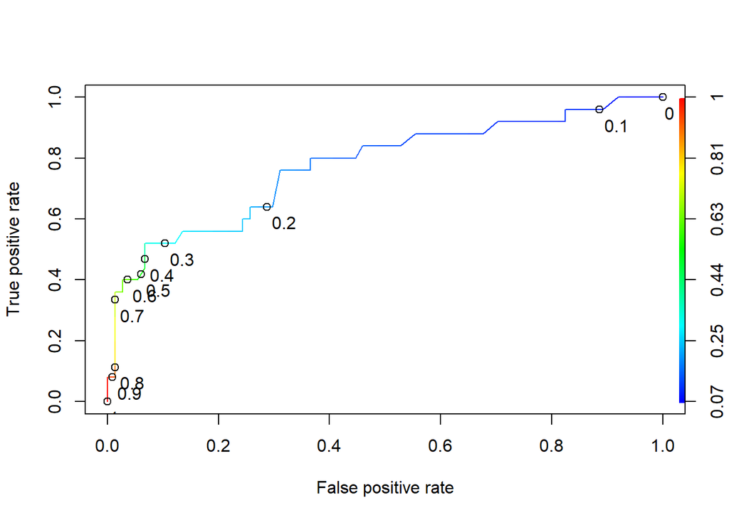

```r
ROCRpred = prediction(predictTrain, qualityTrain$PoorCare)
# 先放預測，再放真的值

ROCRperf = performance(ROCRpred, measure = 'tpr', x.measure = 'fpr')
# measure = 'tpr', x.measure = 'fpr'  先放Y軸再放X軸

plot(ROCRperf, colorize = TRUE)
plot(ROCRperf, colorize = TRUE,
     print.cutoffs.at = seq(0,1,0.1),text.adj = c(-0.2,1.7))
```

```r
# print.cutoffs.at = seq(0,1,0.1) 閾值的數字
# text.adj = c(-0.2,1.7) 讓字跟點分開
```

## Quick Question

This question will ask about the following ROC curve:

Given this ROC curve

Which threshold would you pick if you wanted to correctly identify a small group of patients who are receiving the worst care with high confidence?

Which threshold would you pick if you wanted to correctly identify half of the patients receiving poor care,while making as few errors as possible?

```r
# receiving the worst care with high confidence
# threshold = 0.7

# half of the patients receiving poor care,while making as few errors as possible
# threshold = 0.3
```

## Interpreting (解釋) the Model

multicollinearity:多重共線性

## Quick Question

Compute the test set predictions in R by running the command:

predictTest = predict(QualityLog, type=“response”, newdata=qualityTest)

You can compute the test set AUC by running the following two commands in R:

ROCRpredTest = prediction(predictTest, qualityTest$PoorCare)

auc = as.numeric(performance(ROCRpredTest, “auc”)@y.values)

What is the AUC of this model on the test set?

```r
predictTest = predict(QualityLog, type="response",
                      newdata=qualityTest)

ROCRpredTest = prediction(predictTest, qualityTest$PoorCare)

auc = as.numeric(performance(ROCRpredTest, "auc")@y.values)
auc
```

```
## [1] 0.7994792
```

The AUC of a model has the following nice interpretation: given a random patient from the dataset who actually received poor care, and a random patient from the dataset who actually received good care, the AUC is the perecentage of time that our model will classify which is which correctly.